# Exploratory Data Analysis on Worldwide Vaccine Data

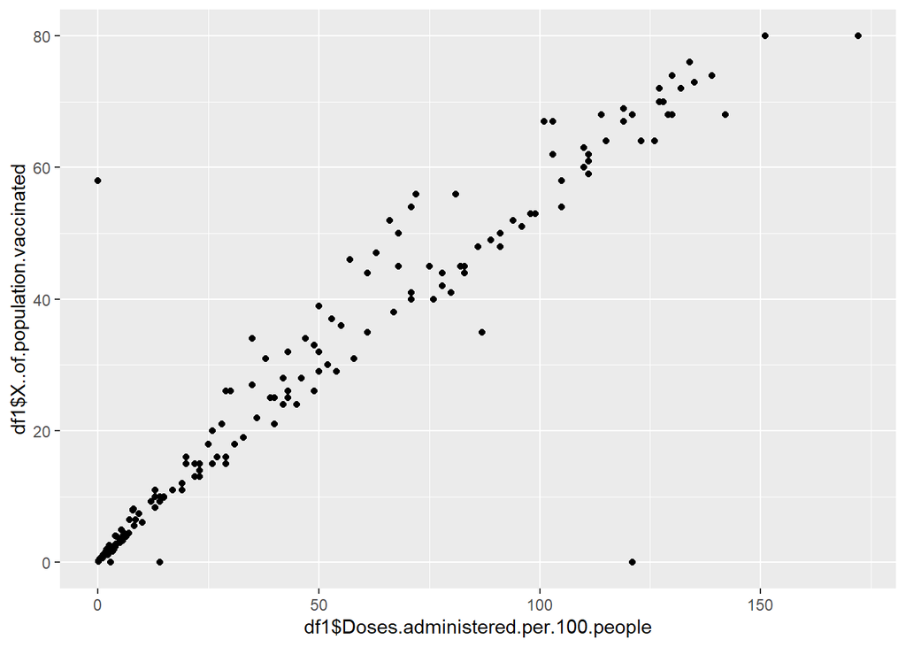

```r
ggplot(data = NULL, aes(x = df1$Doses.administered.per.100.people, y = df1$X..of.population.vaccinated))+geom_point()
```

## Cleveland Dot charts

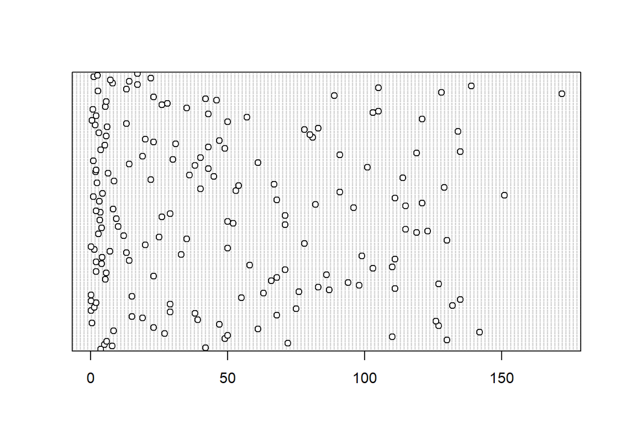

```r
dotchart(df$Doses.administered.per.100.people)
```

## Line plot

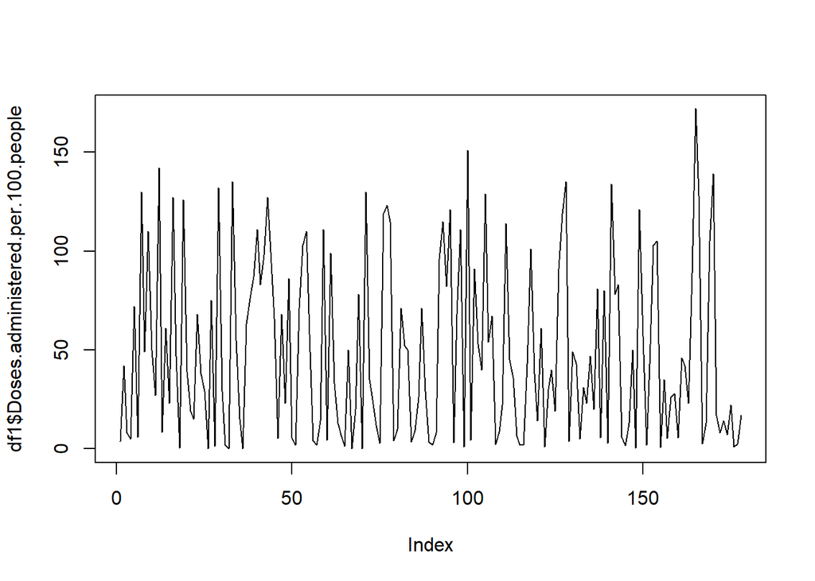

```r
plot(df1$Doses.administered.per.100.people, type = 'l' )
```

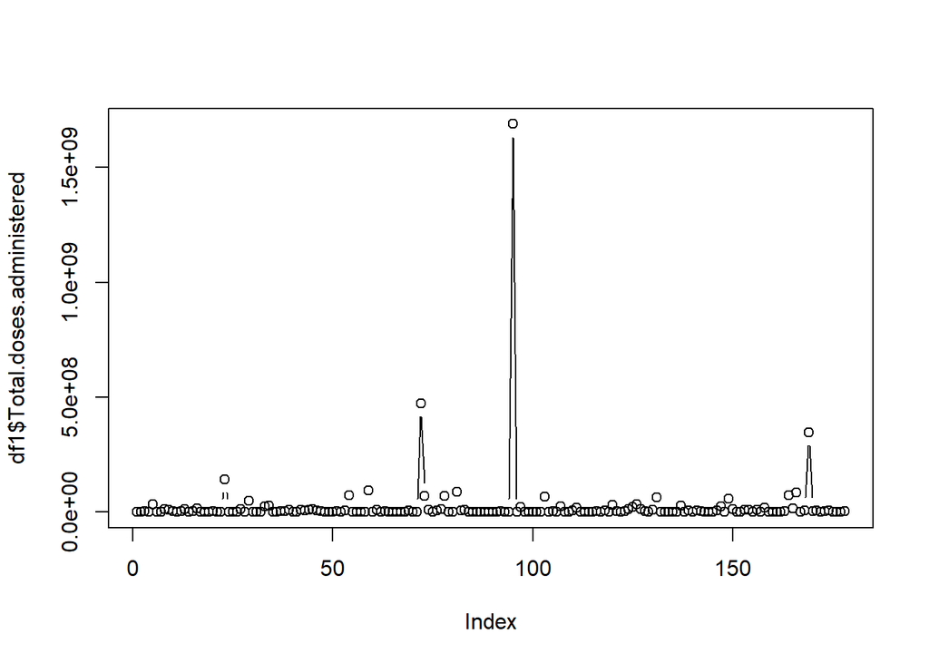

```r
plot(df1$Total.doses.administered, type = 'b')
```

## Cleveland Dot Charts

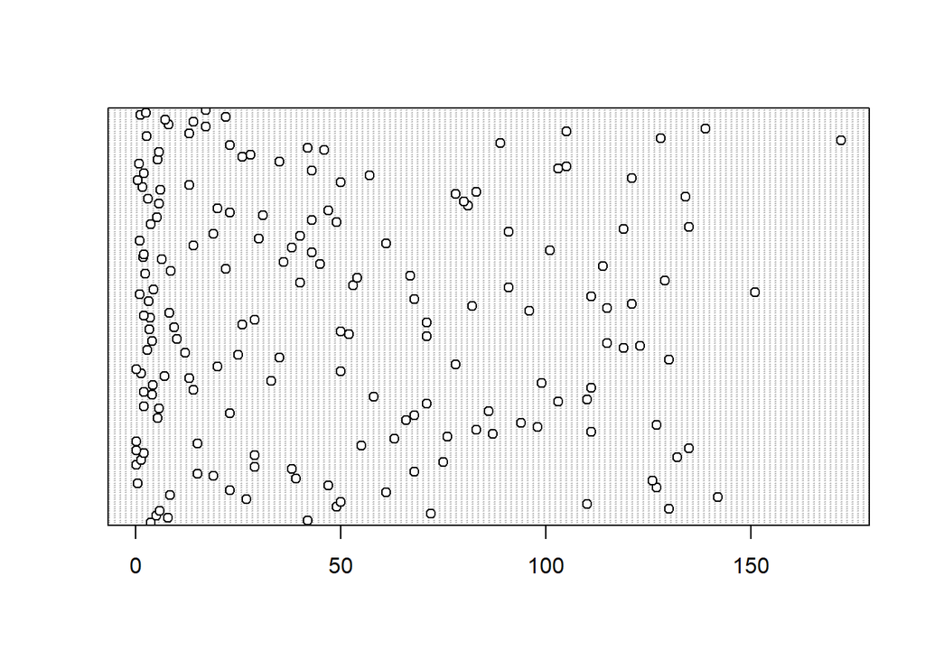

```r
dotchart(df$Doses.administered.per.100.people)
```

## Bar plot

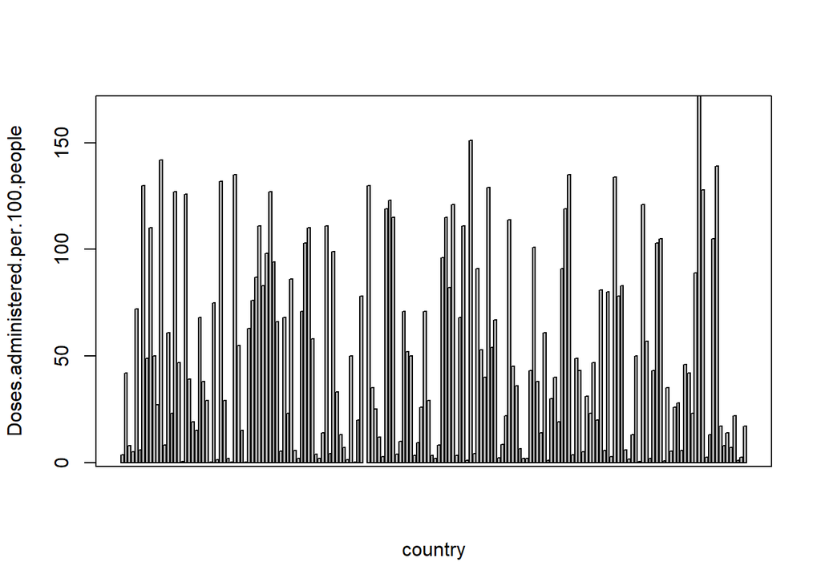

```r
barplot(df$Doses.administered.per.100.people)
title(xlab = 'country',ylab = 'Doses.administered.per.100.people')
box()
```

## table() used to get the column’s diff level(type) counts

```r
table(df$Doses.administered.per.100.people)
```

```
##
## 0.1 0.2 0.5 0.8   1 1.1 1.3 1.6 1.8 1.9   2 2.3 2.5 2.6 2.8 2.9 3.2 3.3 3.4 3.6
##   2   2   2   1   2   1   2   1   1   3   3   1   1   1   1   1   1   1   1   1
## 3.7   4 4.2 4.3   5 5.1 5.3 5.6 5.7 5.8   6 6.4   7 7.2 7.9   8 8.1 8.3 8.5 9.3
##   1   2   1   1   1   1   2   2   1   1   1   1   1   1   1   1   1   1   1   1
##  10  12  13  14  15  17  19  20  22  23  25  26  27  28  29  30  31  33  35  36
##   1   1   3   3   2   2   2   2   2   4   1   2   1   1   3   1   1   1   2   1
##  38  39  40  42  43  45  46  47  49  50  52  53  54  55  57  58  61  63  66  67
##   2   1   2   2   3   1   1   2   2   4   1   1   1   1   1   1   2   1   1   1
##  68  71  72  75  76  78  80  81  82  83  86  87  89  91  94  96  98  99 101 103
##   3   3   1   1   1   2   1   1   1   2   1   1   1   2   1   1   1   1   1   2
## 105 110 111 114 115 119 121 123 126 127 128 129 130 132 134 135 139 142 151 172
##   2   2   3   1   2   2   2   1   1   2   1   1   2   1   1   2   1   1   1   1
```

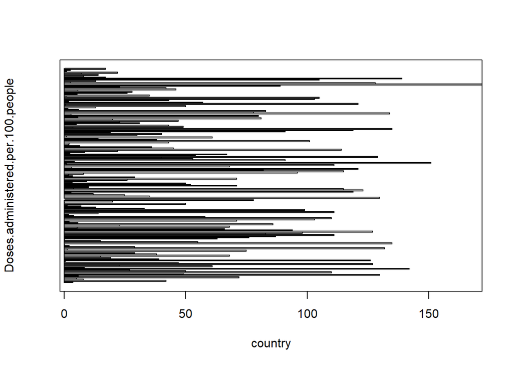

```r
barplot(df$Doses.administered.per.100.people, horiz = T)
title(xlab = 'country', ylab = 'Doses.administered.per.100.people')
box()
```

## the analysis of variance using the aov() command

```r
temp.aov = na.omit(aov(df1$Doses.administered.per.100.people ~ df1$Total.doses.administered, data = df1))
temp.aov
```

```
## Call:
##    aov(formula = df1$Doses.administered.per.100.people ~ df1$Total.doses.administered,
##     data = df1)
##
## Terms:
##                 df1$Total.doses.administered Residuals
## Sum of Squares                       11000.4  344411.2
## Deg. of Freedom                            1       176
##
## Residual standard error: 44.23665
## Estimated effects may be unbalanced
```

## To see the classic ANOVA table of results you need to use the summary() command like so

```r
summary(temp.aov)
```

```
##                               Df Sum Sq Mean Sq F value Pr(>F)
## df1$Total.doses.administered   1  11000   11000   5.621 0.0188 *
## Residuals                    176 344411    1957
## ---
## Signif. codes:  0 '***' 0.001 '**' 0.01 '*' 0.05 '.' 0.1 ' ' 1
```

```r
factor(df$Doses.administered.per.100.people)
```

```
##   [1] 3.6  42   7.9  5    72   5.8  130  49   110  50   27   142  8.3  61   23
##  [16] 127  47   0.5  126  39   19   15   68   38   29   0.2  75   1.3  132  29
##  [31] 2    0.2  135  55   15   0.1  63   76   87   111  83   98   127  94   66
##  [46] 5.3  68   23   86   5.7  2    71   103  110  58   4    1.9  14   111  4.2
##  [61] 99   33   13   7    1.3  50   0.1  20   78   <NA> 130  35   25   12   2.8
##  [76] 119  123  115  4    10   71   52   50   3.3  9.3  26   71   29   3.4  1.9
##  [91] 8.1  96   115  82   121  3.2  68   111  1    151  4.3  91   53   40   129
## [106] 54   67   2.3  8.5  22   114  45   36   6.4  1.8  2    43   101  38   14
## [121] 61   1    30   40   19   91   119  135  3.7  49   43   5.1  31   23   47
## [136] 20   81   5.6  80   2.9  134  78   83   6    1.6  13   50   0.5  121  57
## [151] 1.9  43   103  105  0.8  35   5.3  26   28   5.6  46   42   23   89   172
## [166] 128  2.6  13   105  139  17   8    14   7.2  22   1.1  2.5  17
## 120 Levels: 0.1 0.2 0.5 0.8 1 1.1 1.3 1.6 1.8 1.9 2 2.3 2.5 2.6 2.8 2.9 ... 172
```

## creating new testCol/testRow for addition as a new column/row to the df object (using rep() command)

```r
testCol = c(rep(df$Doses.administered.per.100.people - df$X..of.population.vaccinated, length(df)))
head(testCol)
```

```
## [1]  1.6 18.0  0.0  2.0 16.0  1.7
```

```r
testRow = c('ind', 1000, 40000, 30, 18)
testRow
```

```
## [1] "ind"   "1000"  "40000" "30"    "18"
```

## Adding Rows or Columns

```r
test = data.frame(df, testCol)
head(test)
```

```
##       Country Doses.administered.per.100.people Total.doses.administered
## 1 Afghanistan                               3.6                  1381416
## 2     Albania                              42.0                  1203087
## 3     Algeria                               7.9                  3421279
## 4      Angola                               5.0                  1592537
## 5   Argentina                              72.0                 32335391
## 6     Armenia                               5.8                   171890
##   X..of.population.vaccinated X..of.population.fully.vaccinated testCol
## 1                         2.0                               0.6     1.6
## 2                        24.0                              19.0    18.0
## 3                         7.9                               1.7     0.0
## 4                         3.0                               2.0     2.0
## 5                        56.0                              16.0    16.0
## 6                         4.1                               1.7     1.7
```

```r
test = df
test['testRow',] = testRow
tail(test)
```

```
##                  Country Doses.administered.per.100.people
## 174              Vietnam                               7.2
## 175     West Bank & Gaza                                22
## 176                Yemen                               1.1
## 177               Zambia                               2.5
## 178             Zimbabwe                                17
## testRow              ind                              1000
##         Total.doses.administered X..of.population.vaccinated
## 174                      6959197                         6.5
## 175                      1007483                          13
## 176                       311483                           1
## 177                       441113                         1.6
## 178                      2433341                          11
## testRow                    40000                          30
##         X..of.population.fully.vaccinated
## 174                                   0.7
## 175                                   8.9
## 176                                   0.1
## 177                                   0.9
## 178                                   5.3
## testRow                                18
```

```r
test = df
test["Test",] = NA
tail(test)
```

```
##               Country Doses.administered.per.100.people
## 174           Vietnam                               7.2
## 175  West Bank & Gaza                              22.0
## 176             Yemen                               1.1
## 177            Zambia                               2.5
## 178          Zimbabwe                              17.0
## Test             <NA>                                NA
##      Total.doses.administered X..of.population.vaccinated
## 174                   6959197                         6.5
## 175                   1007483                        13.0
## 176                    311483                         1.0
## 177                    441113                         1.6
## 178                   2433341                        11.0
## Test                       NA                          NA
##      X..of.population.fully.vaccinated
## 174                                0.7
## 175                                8.9
## 176                                0.1
## 177                                0.9
## 178                                5.3
## Test                                NA
```

```r
x = df[ , 2:4]
head(x)
```

```
##   Doses.administered.per.100.people Total.doses.administered
## 1                               3.6                  1381416
## 2                              42.0                  1203087
## 3                               7.9                  3421279
## 4                               5.0                  1592537
## 5                              72.0                 32335391
## 6                               5.8                   171890
##   X..of.population.vaccinated
## 1                         2.0
## 2                        24.0
## 3                         7.9
## 4                         3.0
## 5                        56.0
## 6                         4.1
```

## Simple Column and Row Summaries

```r
colMeans(x)
```

```
## Doses.administered.per.100.people          Total.doses.administered
##                                NA                                NA
##       X..of.population.vaccinated
##                                NA
```

```r
rowMeans(x)
```

```
##   [1] 4.604739e+05 4.010510e+05 1.140432e+06 5.308483e+05 1.077851e+07
##   [6] 5.729997e+04 4.629533e+04 4.131325e+06 3.249299e+06 1.680567e+06
##  [11] 3.485467e+04 7.744147e+05 4.485129e+06 5.867967e+04 7.316767e+05
##  [16] 4.847199e+06 6.122067e+04 1.929563e+04 3.211833e+05 1.508747e+06
##  [21] 2.038907e+05 1.174773e+05 4.751986e+07 5.468933e+04 6.795517e+05
##  [26] 1.237347e+04 4.142375e+06 1.106258e+05 1.652208e+07 5.316700e+04
##  [31] 3.126460e+04 9.993433e+03 8.549915e+06 9.250429e+06 4.199500e+04
##  [36] 2.712807e+04 1.064668e+06 1.026945e+06 3.298057e+06 5.843300e+04
##  [41] 3.315060e+05 3.472532e+06 2.460455e+06 3.382817e+06 3.806641e+06
##  [46] 1.779172e+06 1.464841e+06 1.021003e+05 3.789227e+05 2.189200e+04
##  [51] 7.390337e+05 2.096493e+05 1.886926e+06 2.469043e+07 5.385700e+04
##  [56] 2.906247e+04 1.452007e+04 1.689344e+05 3.079232e+07 4.238000e+05
##  [61] 3.529516e+06 1.219200e+04 7.361083e+05 2.997561e+05 8.409167e+03
##  [66] 1.298060e+05 2.192067e+03 6.374227e+05 1.929320e+06           NA
##  [71] 1.568593e+05 1.574079e+08 2.287365e+07 3.389565e+06 3.626235e+05
```

[output cut: 21 more lines]

```r
colSums(x)
```

```
## Doses.administered.per.100.people          Total.doses.administered
##                                NA                                NA
##       X..of.population.vaccinated
##                                NA
```

```r
rowSums(x)
```

```
##   [1]   1381421.6   1203153.0   3421294.8   1592545.0  32335519.0    171899.9
##   [7]    138886.0  12393975.0   9747897.0   5041701.0    104564.0   2323244.0
##  [13]  13455386.9    176039.0   2195030.0  14541598.0    183662.0     57886.9
##  [19]    963550.0   4526241.0    611672.0    352431.9 142559588.0    164068.0
##  [25]   2038655.0     37120.4  12427125.0    331877.4  49566238.0    159501.0
##  [31]     93793.8     29980.3  25649746.0  27751288.0    125985.0     81384.2
##  [37]   3194005.0   3080835.0   9894172.0    175299.0    994518.0  10417595.0
##  [43]   7381364.0  10148451.0  11419924.0   5337515.0   4394523.0    306301.0
##  [49]   1136768.0     65676.0   2217101.0    628948.0   5660777.0  74071299.0
##  [55]    161571.0     87187.4     43560.2    506803.3  92376960.0   1271400.0
##  [61]  10588549.0     36576.0   2208325.0    899268.4     25227.5    389418.0
##  [67]      6576.2   1912268.0   5787961.0          NA    470578.0 472223701.0
##  [73]  68620951.0  10168695.3   1087870.6   5871297.0  11172123.0  69200958.0
##  [79]   1019906.0    300918.1  89112101.0   5265156.0   9266778.0   1726198.3
##  [85]    600474.7   1895079.0   1358329.0   1982201.0     72953.1     95426.6
##  [91]    546761.2   2678430.0    710691.0    516501.0          NA    594338.6
##  [97]  21669112.0    591126.0    196863.7    760648.0    193784.2   1156623.0
## [103]  67594475.0   1051099.0   4171743.0    333098.0  24257415.0    691043.5
## [109]    211425.0   6163499.0  19751757.0    130147.0   1759212.0    415650.3
## [115]    423338.4   3938948.3    904651.0   5407626.0   1887490.0          NA
## [121]   2573331.0     88344.9   2124053.0  13152350.0  20863574.0  34463875.0
## [127]  12258940.0   3832019.0    198704.2   9413494.0  62369517.0    646917.5
## [133]     57115.0     25672.0     92496.0     43995.0  27810625.0    906566.5
## [139]   5536291.0          NA   7638489.0   4264992.0   1735829.0     40414.4
## [145]    249792.7   7567780.0  26000386.0     56990.0  56796058.0  12331971.0
## [151]    810563.4    248693.0  10565523.0   8984163.0    131222.5   8405154.0
## [157]    492076.3  18198871.0    363318.0    454217.4     47627.0    590899.0
## [163]   2663476.0  73887519.0  16832273.0  85336634.0   1143768.2   5757965.3
## [169] 346924508.0   4806454.0   5803283.0     24011.0   4000024.0   6959210.7
## [175]   1007518.0    311485.1    441117.1   2433369.0
```

## The apply() command to apply a function over all the rows or columns of a data frame (or matrix)

```r
apply(df1[ , 2:3], 2, mean)
```

```
## Doses.administered.per.100.people          Total.doses.administered
##                      4.841629e+01                      2.356872e+07
```

```r
apply(df1[ , 2:3], 1, mean)
```

```
##   [1]    690709.80    601564.50   1710643.45    796271.00  16167731.50
##   [6]     85947.90     69409.00   6196971.00   4873918.50   2520836.00
##  [11]     52274.00   1161588.00   6727690.65     88002.00   1097508.00
##  [16]   7270764.00     91814.00     28943.25    481743.00   2263108.00
##  [21]    305830.00    176211.00  71279769.00     82018.50   1019320.00
##  [26]     18560.10   6213540.00    165938.15  24783083.00     79737.50
##  [31]     46896.00     14990.10  12824836.50  13875626.00     62987.50
##  [36]     40692.05   1596979.00   1540397.50   4947068.50     87620.00
##  [41]    497236.50   5208771.00   3690646.00   5074199.50   5709936.00
##  [46]   2668755.65   2197239.00    153144.00    568360.00     32836.35
##  [51]   1108549.50    314447.00   2830355.00  37035618.00     80770.00
##  [56]     43592.50     21779.45    253397.00  46188449.00    635698.60
##  [61]   5294248.00     18278.50   1104157.00    449632.00     12613.15
##  [66]    194693.00      3288.05    956126.00   2893958.50         0.00
##  [71]    235252.00 236111837.00  34310466.50   5084343.00    543934.40
```

[output cut: 21 more lines]

```r
apply(df1[ , 2:3], 2, median)
```

```
## Doses.administered.per.100.people          Total.doses.administered
##                                37                           1747428
```

```r
apply(df1[ , 2:3], 2, var)
```

```
## Doses.administered.per.100.people          Total.doses.administered
##                      2.007975e+03                      1.800381e+16
```

## Using tapply() to Summarize Using a Grouping Variable

```r
tapply(df1$Doses.administered.per.100.people, df1$Country, FUN = mean)
```

```
##                      Afghanistan                          Albania
##                              3.6                             42.0
##                          Algeria                           Angola
##                              7.9                              5.0
##                        Argentina                          Armenia
##                             72.0                              5.8
##                            Aruba                        Australia
##                            130.0                             49.0
##                          Austria                       Azerbaijan
##                            110.0                             50.0
##                          Bahamas                          Bahrain
##                             27.0                            142.0
##                       Bangladesh                         Barbados
##                              8.3                             61.0
##                          Belarus                          Belgium
##                             23.0                            127.0
##                           Belize                            Benin
##                             47.0                              0.5
##                           Bhutan                          Bolivia
##                            126.0                             39.0
##           Bosnia and Herzegovina                         Botswana
##                             19.0                             15.0
##                           Brazil                           Brunei
##                             68.0                             38.0
##                         Bulgaria                     Burkina Faso
##                             29.0                              0.2
##                         Cambodia                         Cameroon
##                             75.0                              1.3
##                           Canada                       Cape Verde
##                            132.0                             29.0
##         Central African Republic                             Chad
##                              2.0                              0.2
##                            Chile                         Colombia
##                            135.0                             55.0
##                          Comoros                            Congo
##                             15.0                              0.1
##                       Costa Rica                          Croatia
##                             63.0                             76.0
##                             Cuba                         CuraÃ§ao
##                             87.0                            111.0
```

[output cut: 123 more lines]

```
##                             23.0                             89.0
##                           U.A.E.                             U.K.
##                            172.0                            128.0
##                           Uganda                          Ukraine
##                              2.6                             13.0
##                    United States                          Uruguay
##                            105.0                            139.0
##                       Uzbekistan                          Vanuatu
##                             17.0                              8.0
##                        Venezuela                          Vietnam
##                             14.0                              7.2
##                 West Bank & Gaza                            Yemen
##                             22.0                              1.1
##                           Zambia                         Zimbabwe
##                              2.5                             17.0
```

```r
tapply(df1$Doses.administered.per.100.people, df1$Total.doses.administered, FUN = var)
```

```
##          0       6576      23995      25225      25635      29980      36524
##         NA         NA         NA         NA         NA         NA         NA
##      37120      40404      43557      43960      47553      56989      57066
##         NA         NA         NA         NA         NA         NA         NA
##      57886      65667      72948      81384      87181      88343      92415
##         NA         NA         NA         NA         NA         NA         NA
##      93790      95423     104521     125960     130078     131221     138688
##         NA         NA         NA         NA         NA         NA         NA
##     159446     161482     163999     171890     175129     175943     183581
##         NA         NA         NA         NA         NA         NA         NA
##     193776     196862     198698     211410     225380     248618     249790
##         NA         NA         NA         NA         NA         NA         NA
##     300902     306265     311483     331875     333015     352407     363269
##         NA         NA         NA         NA         NA         NA         NA
##     389336     415640     423335     441113     454208     470374     492066
##         NA         NA         NA         NA         NA         NA         NA
##     506780     516374     546745     590829     590954     594333     600458
##         NA         NA         NA         NA         NA         NA         NA
##     611641     628823     646909     691040     710512     760417     810560
##         NA         NA         NA         NA         NA         NA         NA
##     899257     904583     906557     963360     994390    1007483    1019898
##         NA         NA         NA         NA         NA         NA         NA
##    1051038    1087866    1136634    1143763    1156482    1203087    1271393
##         NA         NA         NA         NA         NA         NA         NA
##    1358218    1381416    1592537    1726193    1735702    1759154    1887421
##         NA         NA         NA         NA         NA         NA         NA
##    1895038    1912232    1982156    2038611    2123997    2194993    2208301
##         NA         NA         NA         NA         NA         NA         NA
##    2217097    2323034    2433341    2573226    2663438    2678283    3080719
##         NA         NA         NA         NA         NA         NA         NA
##    3193895    3421279    3831811    3938945      4e+06    4171546    4264872
##         NA         NA         NA         NA         NA         NA         NA
##    4394410    4526177    4806241    5041622    5265074    5337506    5407458
##         NA         NA         NA         NA         NA         NA         NA
##    5536170    5660607    5757944    5787839    5803255    5871111    6163462
##         NA         NA         NA         NA         NA         NA         NA
##    6959197    7381165    7567757    7638279    8405085    8984004    9266699
##         NA         NA         NA         NA         NA         NA         NA
##    9413419    9747727    9894050   10148305   10168674   10417444   10565358
##         NA         NA         NA         NA         NA         NA         NA
##   10588397   11171936   11419806   12258752   12331868   12393893   12427005
##         NA         NA         NA         NA         NA         NA         NA
##   13152285   13455373   14541401   16832021   18198825   19751575   20863544
##         NA         NA         NA         NA         NA         NA         NA
##   21668999   24257310   25649538   26000297   27751197   27810488   30590183
##         NA         NA         NA         NA         NA         NA         NA
##   32335391   34463736   49566034   56795869   62369448   67594385   68620908
##         NA         NA         NA         NA         NA         NA         NA
##   69200779   73887381   74071126   85336436   89111989   92376787  142559470
##         NA         NA         NA         NA         NA         NA         NA
##  346924345  472223639 1688683000
##         NA         NA         NA
```

```r
tapply(df1$Doses.administered.per.100.people, df1$X..of.population.vaccinated, FUN = mean)
```

```
##           0         0.1         0.2         0.4         0.5         0.7
##  45.9666667   0.1333333   0.2000000   0.5000000   0.5000000   0.9000000
##         0.9           1         1.1         1.2         1.3         1.5
##   1.0000000   1.1000000   1.4500000   1.8000000   1.9500000   1.9000000
##         1.6         1.7         1.8           2         2.4         2.5
##   2.1500000   2.6500000   2.4000000   2.9666667   3.6000000   3.7000000
##         2.6         2.8           3         3.3         3.4         3.7
##   2.6000000   4.2000000   5.0000000   5.7000000   5.1000000   5.3000000
##         3.8         3.9           4         4.1         4.4           5
##   5.6000000   5.4333333   4.0000000   5.8000000   6.5000000   5.3000000
##         5.6         6.1         6.5         7.4         7.9           8
##   8.3000000  10.0000000   7.8500000   9.3000000   7.9000000   8.0000000
##         8.1         8.3         9.3         9.9          10          11
##   8.1000000  13.0000000  13.0000000  15.0000000  14.0000000  16.5000000
##          12          13          14          15          16          18
##  19.0000000  22.5000000  23.0000000  24.0000000  25.3333333  28.0000000
##          19          20          21          22          24          25
##  33.0000000  26.0000000  34.0000000  36.0000000  43.5000000  40.6666667
##          26          27          28          29          30          31
##  37.7500000  35.0000000  44.0000000  51.3333333  52.0000000  44.6666667
##          32          33          34          35          36          37
##  46.5000000  49.0000000  43.0000000  74.0000000  55.0000000  53.0000000
##          38          39          40          41          42          44
##  67.0000000  50.0000000  73.5000000  75.5000000  78.0000000  74.0000000
##          45          46          47          48          49          50
##  75.2000000  57.0000000  63.0000000  88.5000000  89.0000000  79.5000000
##          51          52          53          54          56          58
##  96.0000000  80.0000000  98.5000000  88.0000000  76.5000000  52.5000000
##          59          60          61          62          63          64
## 111.0000000 110.0000000 111.0000000 107.0000000 110.0000000 119.7500000
##          67          68          69          70          72          73
## 107.6666667 127.2000000 119.0000000 127.5000000 129.5000000 135.0000000
##          74          76          80
## 134.5000000 134.0000000 161.5000000
```

```r
tapply(df1$Doses.administered.per.100.people, df1$X..of.population.fully.vaccinated, FUN = mean)
```

```
##          0        0.1        0.2        0.3        0.4        0.5        0.6
##  23.433333   1.254545   1.733333   3.100000   1.900000   1.900000   2.600000
##        0.7        0.9          1        1.1        1.2        1.3        1.6
##   4.133333   2.500000   2.800000   2.300000   3.700000   3.750000   5.225000
##        1.7        1.9          2        2.4        2.5        2.6        2.7
##  13.025000   7.450000   7.900000   5.700000   6.400000   7.000000   8.300000
##        2.9          3        3.2        3.3        3.9        4.1        4.3
##  12.000000  15.500000  20.000000  29.000000  14.000000  20.000000  14.000000
##        4.7        4.8        5.1        5.3        5.4        5.5        5.7
##  13.000000  15.000000  13.000000  17.000000  15.000000  20.000000  26.000000
##        6.7        6.8          7        7.6        7.7        8.2        8.4
##  33.000000  38.000000  20.500000  35.000000  25.000000  23.000000  19.000000
##        8.9          9        9.1        9.4         10         11         12
##  22.000000  23.000000  23.000000  23.000000  57.000000  35.000000  27.500000
##         13         14         15         16         17         18         19
##  47.000000  40.750000  49.000000  61.000000  63.000000  46.333333  41.666667
##         20         21         22         23         24         25         26
##  60.500000  48.333333  52.000000  74.333333  55.000000  61.333333  58.000000
##         27         28         30         33         34         35         36
##  61.000000  67.000000  73.000000  83.500000 101.000000  76.000000  87.000000
##         37         38         39         41         45         46         48
##  82.000000  83.000000  85.666667  97.000000  96.000000  94.500000 107.500000
##         49         50         51         52         53         55         56
##  99.000000 109.500000 113.000000 110.666667 115.000000 127.000000  79.333333
##         58         59         60         62         63         65         70
## 124.500000 125.000000 133.000000 131.333333 126.000000 138.666667 130.000000
##         72         76
## 172.000000 151.000000
```

```r
tapply(df1$X..of.population.fully.vaccinated, df1$X..of.population.vaccinated, FUN = mean)
```

```
##          0        0.1        0.2        0.4        0.5        0.7        0.9
##  1.0000000  0.1000000  0.1000000  0.1000000  0.1000000  0.2000000  0.1000000
##          1        1.1        1.2        1.3        1.5        1.6        1.7
##  0.1000000  0.4000000  0.6000000  0.6000000  0.4000000  0.6000000  0.9500000
##        1.8          2        2.4        2.5        2.6        2.8          3
##  0.6000000  0.6333333  1.1500000  1.2000000  0.0000000  1.3000000  2.0000000
##        3.3        3.4        3.7        3.8        3.9          4        4.1
##  2.4000000  2.0000000  1.6000000  1.9000000  1.4666667  0.0000000  1.7000000
##        4.4          5        5.6        6.1        6.5        7.4        7.9
##  2.1000000  0.3000000  2.7000000  4.1000000  1.3500000  1.9000000  1.7000000
##          8        8.1        8.3        9.3        9.9         10         11
##  0.1000000  0.0000000  4.7000000  3.6000000  5.4000000  4.6000000  4.6750000
##         12         13         14         15         16         18         19
##  7.0000000  9.1500000  9.0500000  9.3400000  8.7333333 10.8500000 14.0000000
##         20         21         22         24         25         26         27
##  5.7000000 12.8500000 14.0000000 20.0000000 16.3333333 12.6000000  7.6000000
##         28         29         30         31         32         33         34
## 16.0000000 22.3333333 22.0000000 13.1666667 14.5000000 15.0000000  9.2333333
##         35         36         37         38         39         40         41
## 25.0000000 24.0000000 20.0000000 28.0000000 14.0000000 35.5000000 34.5000000
##         42         44         45         46         47         48         49
## 37.0000000 29.3333333 30.2000000 10.0000000 17.0000000 41.5000000 33.0000000
##         50         51         52         53         54         56         58
## 30.5000000 45.0000000 26.5000000 47.5000000 32.0000000 20.5000000 53.0000000
##         59         60         61         62         63         64         67
## 52.0000000 52.0000000 51.0000000 46.5000000 48.0000000 56.5000000 42.0000000
##         68         69         70         72         73         74         76
## 59.4000000 56.0000000 58.5000000 57.5000000 63.5000000 67.5000000 60.0000000
##         80
## 74.0000000
```

```r
tapply(df1$Total.doses.administered, df1$Total.doses.administered, FUN = mean)
```

```
##          0       6576      23995      25225      25635      29980      36524
##          0       6576      23995      25225      25635      29980      36524
##      37120      40404      43557      43960      47553      56989      57066
##      37120      40404      43557      43960      47553      56989      57066
##      57886      65667      72948      81384      87181      88343      92415
##      57886      65667      72948      81384      87181      88343      92415
##      93790      95423     104521     125960     130078     131221     138688
##      93790      95423     104521     125960     130078     131221     138688
##     159446     161482     163999     171890     175129     175943     183581
##     159446     161482     163999     171890     175129     175943     183581
##     193776     196862     198698     211410     225380     248618     249790
##     193776     196862     198698     211410     225380     248618     249790
##     300902     306265     311483     331875     333015     352407     363269
##     300902     306265     311483     331875     333015     352407     363269
##     389336     415640     423335     441113     454208     470374     492066
```

[output cut: 37 more lines]

## The aggregate() command enables you to compute summary statistics for subsets of a data frame or matrix; the result comes out as a single matrix rather than an array item, even with multiple grouping factors

```r
aggregate(df[ , 2:4], by = list(df$Country), FUN = mean)
```

```
##                              Group.1 Doses.administered.per.100.people
## 1                        Afghanistan                               3.6
## 2                            Albania                              42.0
## 3                            Algeria                               7.9
## 4                             Angola                               5.0
## 5                          Argentina                              72.0
## 6                            Armenia                               5.8
## 7                              Aruba                             130.0
## 8                          Australia                              49.0
## 9                            Austria                             110.0
## 10                        Azerbaijan                              50.0
## 11                           Bahamas                              27.0
## 12                           Bahrain                             142.0
## 13                        Bangladesh                               8.3
## 14                          Barbados                              61.0
```

[output cut: 343 more lines]

```r
aggregate(df[ , 2:4], by = list(df$Doses.administered.per.100.people), FUN = mean)
```

```
##     Group.1 Doses.administered.per.100.people Total.doses.administered
## 1       0.1                               0.1                  43980.0
## 2       0.2                               0.2                  33550.0
## 3       0.5                               0.5                  57437.5
## 4       0.8                               0.8                 131221.0
## 5       1.0                               1.0                 142602.5
## 6       1.1                               1.1                 311483.0
## 7       1.3                               1.3                 178550.0
## 8       1.6                               1.6                 249790.0
## 9       1.8                               1.8                 423335.0
## 10      1.9                               1.9                 316513.3
## 11      2.0                               2.0                2083277.3
## 12      2.3                               2.3                 691040.0
## 13      2.5                               2.5                 441113.0
## 14      2.6                               2.6                1143763.0
```

[output cut: 227 more lines]

```r
aggregate(df[ , 2:4], by = list(df$Total.doses.administered), FUN = mean)
```

```
##        Group.1 Doses.administered.per.100.people Total.doses.administered
## 1         6576                               0.1                     6576
## 2        23995                               8.0                    23995
## 3        25225                               1.3                    25225
## 4        25635                              23.0                    25635
## 5        29980                               0.2                    29980
## 6        36524                              33.0                    36524
## 7        37120                               0.2                    37120
## 8        40404                               6.0                    40404
## 9        43557                               1.9                    43557
## 10       43960                              20.0                    43960
## 11       47553                              46.0                    47553
## 12       56989                               0.5                    56989
## 13       57066                              31.0                    57066
## 14       57886                               0.5                    57886
```

[output cut: 341 more lines]

```r
aggregate(df[ , 2:4], by = list(df$X..of.population.vaccinated), FUN = mean)
```

```
##    Group.1 Doses.administered.per.100.people Total.doses.administered
## 1      0.1                         0.1333333                 39313.33
## 2      0.2                         0.2000000                 37120.00
## 3      0.4                         0.5000000                 57886.00
## 4      0.5                         0.5000000                 56989.00
## 5      0.7                         0.9000000                164041.50
## 6      0.9                         1.0000000                 88343.00
## 7      1.0                         1.1000000                311483.00
## 8      1.1                         1.4500000                290832.50
## 9      1.2                         1.8000000                358132.50
## 10     1.3                         1.9500000               1991251.00
## 11     1.5                         1.9000000                810560.00
## 12     1.6                         2.1500000                432224.00
## 13     1.7                         2.6500000                 84185.50
## 14     1.8                         2.4000000                590828.00
```

[output cut: 183 more lines]

```r
aggregate(df[ , 2:4], by = list(df$X..of.population.fully.vaccinated), FUN = mean)
```

```
##    Group.1 Doses.administered.per.100.people Total.doses.administered
## 1      0.1                          1.254545                 77291.09
## 2      0.2                          1.733333                173696.00
## 3      0.3                          3.100000                326509.75
## 4      0.4                          1.900000                810560.00
## 5      0.5                          1.900000                 43557.00
## 6      0.6                          2.600000                815603.00
## 7      0.7                          4.133333               3830825.00
## 8      0.9                          2.500000                441113.00
## 9      1.0                          2.800000               1087866.00
## 10     1.1                          2.300000                691040.00
## 11     1.2                          3.700000                198698.00
## 12     1.3                          3.750000               1498793.00
## 13     1.6                          5.225000               1592912.00
## 14     1.7                         13.025000               3017800.50
```

[output cut: 171 more lines]

## uding cbind()

```r
aggregate(cbind(df$Doses.administered.per.100.people, df$Total.doses.administered), data = df, by = list(df$Country), FUN = mean)
```

```
##                              Group.1    V1         V2
## 1                        Afghanistan   3.6    1381416
## 2                            Albania  42.0    1203087
## 3                            Algeria   7.9    3421279
## 4                             Angola   5.0    1592537
## 5                          Argentina  72.0   32335391
## 6                            Armenia   5.8     171890
## 7                              Aruba 130.0     138688
## 8                          Australia  49.0   12393893
## 9                            Austria 110.0    9747727
## 10                        Azerbaijan  50.0    5041622
## 11                           Bahamas  27.0     104521
## 12                           Bahrain 142.0    2323034
## 13                        Bangladesh   8.3   13455373
## 14                          Barbados  61.0     175943
```

[output cut: 164 more lines]

```r
aggregate(df$X..of.population.fully.vaccinated ~ df$Country, data = df, FUN = mean)
```

```
##                           df$Country df$X..of.population.fully.vaccinated
## 1                        Afghanistan                                  0.6
## 2                            Albania                                 19.0
## 3                            Algeria                                  1.7
## 4                             Angola                                  2.0
## 5                          Argentina                                 16.0
## 6                            Armenia                                  1.7
## 7                              Aruba                                 62.0
## 8                          Australia                                 15.0
## 9                            Austria                                 52.0
## 10                        Azerbaijan                                 21.0
## 11                           Bahamas                                 11.0
## 12                           Bahrain                                 65.0
## 13                        Bangladesh                                  2.7
## 14                          Barbados                                 27.0
```

[output cut: 158 more lines]

```r
aggregate(df$Total.doses.administered ~ df$Country * df$X..of.population.vaccinated, data = df, FUN = mean)
```

```
##                           df$Country df$X..of.population.vaccinated
## 1                               Chad                            0.1
## 2                              Congo                            0.1
## 3                              Haiti                            0.1
## 4                       Burkina Faso                            0.2
## 5                              Benin                            0.4
## 6                        South Sudan                            0.5
## 7                               Mali                            0.7
## 8                              Syria                            0.7
## 9                   Papua New Guinea                            0.9
## 10                             Yemen                            1.0
## 11                          Cameroon                            1.1
## 12                           Somalia                            1.1
## 13                     Guinea-Bissau                            1.2
## 14                        Mozambique                            1.2
```

[output cut: 335 more lines]

## The na.omit() command strips out unwanted NA items from vectors and data frames.

```r
head(na.omit(df))
```

```
##       Country Doses.administered.per.100.people Total.doses.administered
## 1 Afghanistan                               3.6                  1381416
## 2     Albania                              42.0                  1203087
## 3     Algeria                               7.9                  3421279
## 4      Angola                               5.0                  1592537
## 5   Argentina                              72.0                 32335391
## 6     Armenia                               5.8                   171890
##   X..of.population.vaccinated X..of.population.fully.vaccinated
## 1                         2.0                               0.6
## 2                        24.0                              19.0
## 3                         7.9                               1.7
## 4                         3.0                               2.0
## 5                        56.0                              16.0
## 6                         4.1                               1.7
```

## ls and objects return a vector of character strings giving the names of the objects in the specified environment

```r
objects(df)
```

```
## [1] "Country"                           "Doses.administered.per.100.people"
## [3] "Total.doses.administered"          "X..of.population.fully.vaccinated"
## [5] "X..of.population.vaccinated"
```

```r
ls(df)
```

```
## [1] "Country"                           "Doses.administered.per.100.people"
## [3] "Total.doses.administered"          "X..of.population.fully.vaccinated"
## [5] "X..of.population.vaccinated"
```

## Simple lineaR RegReSSion

```r
dflm = lm(Doses.administered.per.100.people ~ X..of.population.vaccinated, data = df)
dflm
```

```
##
## Call:
## lm(formula = Doses.administered.per.100.people ~ X..of.population.vaccinated,
##     data = df)
##
## Coefficients:
##                 (Intercept)  X..of.population.vaccinated
##                      -3.274                        1.806
```

```r
cor.test(~ df$Doses.administered.per.100.people + df$X..of.population.vaccinated, data = df)
```

```
##
##  Pearson's product-moment correlation
##
## data:  df$Doses.administered.per.100.people and df$X..of.population.vaccinated
## t = 71.441, df = 172, p-value < 2.2e-16
## alternative hypothesis: true correlation is not equal to 0
## 95 percent confidence interval:
##  0.9778824 0.9877950
## sample estimates:
##      cor
## 0.983564
```

## Linear Model Results Objects can extract the coefficients using the coef() command

```r
coef(dflm)
```

```
##                 (Intercept) X..of.population.vaccinated
##                   -3.273883                    1.805638
```

## can obtain confidence intervals on these coefficients using the confint() command

```r
confint(dflm)
```

```
##                                 2.5 %    97.5 %
## (Intercept)                 -5.151979 -1.395787
## X..of.population.vaccinated  1.755749  1.855526
```

## Fitted Values

```r
head(fitted(dflm))
```

```
##          1          2          3          4          5          6
##  0.3373923 40.0614194 10.9906541  2.1430299 97.8418224  4.1292312
```

## Residuals

```r
head(residuals(dflm))
```

```
##          1          2          3          4          5          6
##   3.262608   1.938581  -3.090654   2.856970 -25.841822   1.670769
```